# Упрощенная работа с временными периодами с помощью пакета timeperiodsR

Alexey Seleznev

2019-09-16

# Цель пакета timeperiodsR

Зачастую при создании скриптов которые в последвии будут запускаться по рассписанию нам необходимо определить период, как правило таким периодом может быть прошлая неделя, прошлый месяц, какое то количество прошлых дней. Пакет `timeperiodsR` предоставляет вам набор функций которые автоматически будут вычислять такой период от какой либо базовой даты.

# Функции пакета timeperiodsR

## Список функций

- `last_n_days()`
- `last_n_weeks()`
- `last_n_months()`
- `last_n_quarters()`
- `last_n_years()`
- `previous_week()`
- `previous_month()`
- `previous_quarter()`
- `previous_year()`
- `this_week()`
- `this_month()`
- `this_quarter()`
- `this_year()`
- `next_week()`
- `next_month()`
- `next_quarter()`
- `next_year()`
- `next_n_days()`
- `next_n_weeks()`
- `next_n_months()`
- `next_n_quarters()`
- `next_n_years()`

## Компоненты получаемых объектов

Любая из функций пакета возвращает объект класса `tpr` состоящий из следующих компонентов: * start - начальную дату; * end - конечную дату; * sequence - последовательность дат; * length - количество дней входящих в период;

## Аргументы

В функциях пакета timeperiodsR присутвуют следующие аргументы: * *x* - Объект даты, от которой будет вычисляться интервал, по умолчанию это текущий день; * *n* - Количество временных интервалов на которое необходимо сместится от даты указанной в аргументе *x*; * *part* - Какую часть объекта вам необходимо получить: * “all” - объект со всеми доступными компонентами; * “start” - начальную дату; * “end” - конечную дату; * “sequence” - последовательность дат; * “length” - количество дней входящих в период; * *week_start* - Какой день будет являться началом недели: 1 - понедельник, 7 - воскресенье; * *include_current* - Включать ли в период текущий временной объект, TRUE или FALSE.

# last_n_*

Функции блока `last_n_*()` позволяют вам получить прошлый период с заданным количеством временных единиц.

Вместо `*` подставьте один из нужных вам временных интервалов: *days, weeks, months, quarters, years*

Например, допустим, что сегодня 26 сентября 2019 года и вам необходимо получить 2 прошлые недели то используйте функцию `last_n_weeks()`:

```r
library(timeperiodsR)

last2weeks <- last_n_weeks(n = 2)
```

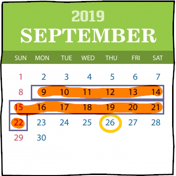

2 прошлые недели

После чего у вас появится объект **last2weeks** класса `tpr`. Из него вы легко можете получить начальную или конечную дату периода, а так же всю последовательность дат которая вошла в этот период, или количество дней вошедших в период.

```r
# начальная дата
last2weeks$start
```

```
## [1] "2019-09-02"
```

```r
# конечная дата
last2weeks$end
```

```
## [1] "2019-09-15"
```

```r
# последовательность дат
last2weeks$sequence
```

```
##  [1] "2019-09-02" "2019-09-03" "2019-09-04" "2019-09-05" "2019-09-06"
##  [6] "2019-09-07" "2019-09-08" "2019-09-09" "2019-09-10" "2019-09-11"
## [11] "2019-09-12" "2019-09-13" "2019-09-14" "2019-09-15"
```

```r
# или
seq(last2weeks)
```

```
##  [1] "2019-09-02" "2019-09-03" "2019-09-04" "2019-09-05" "2019-09-06"
##  [6] "2019-09-07" "2019-09-08" "2019-09-09" "2019-09-10" "2019-09-11"
## [11] "2019-09-12" "2019-09-13" "2019-09-14" "2019-09-15"
```

```r
# количество дней вошедших в период
last2weeks$length
```

```
## [1] 14
```

```r
# или
length(last2weeks)
```

```
## [1] 14
```

Во всех функциях предназначенных для работы с неделями т.е. `last_n_weeks()`, `previous_week()`, `this_week()`, `next_week()`, `next_n_weeks()` присутвует аргумент *week_start*, с помощью которого можно указать день недели который будет являться её началом. По умолчанию неделя начинается с понедельника, т.е. `week_start = 1`, но вы можете задать и любой другой день:

1. Понедельник
2. Вторник
3. Среда
4. Четверг
5. Пятница
6. Суббота
7. Воскресенье

Т.е. если вы хотите получить 2 предыдущие недели отталкиваясь от 26 сентября, и при этом необходимо считать началом неделеи воскресенье то используйте следующий код:

```r
library(timeperiodsR)

last2weeks <- last_n_weeks(x = "2019-09-26", n = 2, week_start = 7)
```

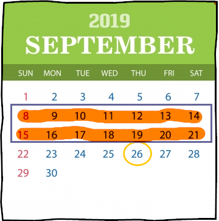

# previous_*

Функции блока `previous_*()` позволяют вам получить прошлый период со смещением на заданное количеством временных единиц. Т.е. например получить позапрошлую неделю.

Вместо `*` подставьте один из нужных вам временных интервалов: *week, month, quarter, year*

Допустим нам необходимо получить позапрошлую неделю отталкиваясь от 26 сентября 2019 года, началом недели должен быть понедельник

```r
previous2weeks <- previous_week(x = "2019-09-26", n = 2)
```

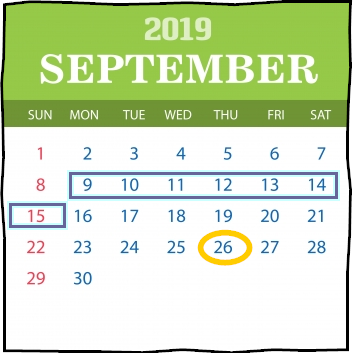

Позапрошлая неделя

# this_*

Функции блока `this_*()` позволяют вам получить текущий период.

Вместо `*` подставьте один из нужных вам временных интервалов: *week, month, quarter, year*

Если вам необходимо получить первую и последнюю дату текущего месяца, и всю последовательность дат которые в него входят то используйте следующий код:

```r
this_month()
```

[output not shown]